# Multi-Level Linguistic Alignment in a Dynamic CPS Tasks: Descriptives

03/30/22

## Notebook contains code for computing level stats on relationship between # of turns, trophy completions, block, and verbosity

#### Step 1: Import main data file and run script to prep variables for analysis

```r
library(tidyverse)
library(pander)
```

```r
main.data = read_csv("../Data/Step1_PrepareFeatures.csv", show_col_types = FALSE)
```

Code below just generates a new variable for how many overall turns were present in each level and adds to the main datasheet

```r
turns = main.data %>% group_by(Team, School, Block, Level, revisited) %>%
  summarise(numberturns = n())
main.data = left_join(main.data, turns)
```

# GENERATE WHAT ACTUALLY APPEARS IN PAPER

```r
## how many original levels
levels1 = main.data %>% select(Team, School, Block, Level, revisited, trophy) %>% distinct(); nrow(levels1)
```

```
## [1] 1089
```

Number of levels after removing short levels of fewer than 20 turns

```r
rmTurns = 20

df.20.more = filter(main.data, numberturns >= rmTurns)
## how many levels after 20 turns, also same data as models
levels2 = filter(main.data, numberturns >= rmTurns) %>% filter(utterlen_aligner < 71 & utterlen_target < 71) %>% select(Team, School, Block, Level, revisited, trophy) %>% distinct(); nrow(levels2)
```

```
## [1] 633
```

Of the longer levels, number of turns and words per turn

```r
# overallturnswords = df.20.more %>% group_by(Team, School, Block, Level, revisited, trophy) %>%
#   summarize_at(c("numberturns", "utterlen_aligner"), list(mean, sd)); overallturnswords

overallturnswords = df.20.more %>% filter(utterlen_aligner < 71 & utterlen_target < 71) %>%
  summarize_at(c("numberturns", "utterlen_aligner"), list(mean, sd)); colnames(overallturnswords) <- c("Mturn", "Mutterlen", "SDturn", "SDutterlen"); overallturnswords
```

```
## # A tibble: 1 × 4
##   Mturn Mutterlen SDturn SDutterlen
##   <dbl>     <dbl>  <dbl>      <dbl>
## 1  76.7      11.1   44.9       10.4
```

Of the longer levels, outcomes based on coins

```r
## how many trophies distributed across reduced levels
levtab2 = table(levels2$trophy);
levtab2
```

```
##
##   gold   none silver
##    108    283    242
```

Generate table showing time and turn information across outcomes, also generate statistical tests comparing these measures for outcomes

```r
levBlotab2 = df.20.more %>% filter(utterlen_aligner < 71 & utterlen_target < 71) %>%
  group_by(trophy) %>%
  summarize_at(c("level_duration", "numberturns"), list(mean = mean, sd = sd)) %>%
  mutate(
    trophy = case_when(
      trophy == "none" ~ "None",
      trophy == "silver" ~ "Silver",
      trophy == "gold" ~ "Gold") %>%
      as.factor %>%
      fct_relevel("None", "Silver", "Gold")
  )
```

```r
p_value_one <- tibble(
  x = c("None", "None", "Silver", "Silver"),
  y = c(775, 800, 800, 775)
)

p_value_two <- tibble(
  x = c("Silver", "Silver", "Gold", "Gold"),
  y = c(625, 650, 650, 625)
)

fig1 = levBlotab2 %>%
  ggplot(aes(trophy, level_duration_mean)) +
  geom_col(aes(fill = trophy), color = "black", width = 0.85) +
  geom_errorbar(aes(ymin = level_duration_mean - level_duration_sd,
                    ymax = level_duration_mean + level_duration_sd),
                color = "#22292F",
                width = .1) +
  geom_line(data = p_value_one,
            aes(x = x, y = y, group = 1)) +
  geom_line(data = p_value_two,
            aes(x = x, y = y, group = 1)) +
  annotate("text", x = 1.5, y = 810,
           label = "***",
           size = 8, color = "#22292F") +
  annotate("text", x = 2.5, y = 660,
           label = "***",
           size = 8, color = "#22292F") +
  scale_fill_grey(start = 0.3) +
  scale_y_continuous(limits = c(0, 865), expand = c(0, 0)) +
  guides(fill = "none") +
  theme_minimal() +
  labs(
    x = "",
    y = "Mean Level Duration",
    title = "Duration",
    # caption = "Error bars indicate standard deviations"
  ) +

  theme_bw() +
  theme(plot.title=element_text(size=14,face="bold"), # theme_light()
        axis.text.y=element_text(size=12),
        axis.ticks.y=element_blank(),
        axis.text.x=element_text(size=12, face="bold"),
        axis.title=element_text(size=12,face="bold"),
        # plot.caption = element_text(hjust = 0),
        strip.text.y = element_text(hjust=0,vjust = 1,angle=180,face="bold"),
    axis.line = element_line(color = "#3D4852"),
    axis.ticks = element_line(color = "#3D4852"),
    panel.grid.major.y = element_line(color = "#DAE1E7"),
    panel.grid.major.x = element_blank(),
    panel.grid.minor.y = element_blank()
  )
```

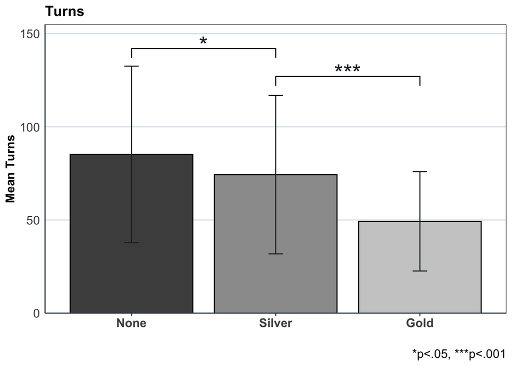

```r
p_value_one <- tibble(
  x = c("Silver", "Silver", "Gold", "Gold"),
  y = c(122, 127, 127, 122)
)

p_value_two <- tibble(
  x = c("None", "None", "Silver", "Silver"),
  y = c(137, 142, 142, 137)
)

fig2 = levBlotab2 %>%
  ggplot(aes(trophy, numberturns_mean)) +
  geom_col(aes(fill = trophy), color = "black", width = 0.85) +
  geom_errorbar(aes(ymin = numberturns_mean - numberturns_sd,
                    ymax = numberturns_mean + numberturns_sd),
                color = "#22292F",
                width = .1) +
  geom_line(data = p_value_one,
            aes(x = x, y = y, group = 1)) +
  geom_line(data = p_value_two,
            aes(x = x, y = y, group = 1)) +
  annotate("text", x = 2.5, y = 129,
           label = "***",
           size = 8, color = "#22292F") +
  annotate("text", x = 1.5, y = 144,
           label = "*",
           size = 8, color = "#22292F") +
  scale_fill_grey(start = 0.3) +
  scale_y_continuous(limits = c(0, 155), expand = c(0, 0)) +
  guides(fill = "none") +
  theme_minimal() +
  labs(
    x = "",
    y = "Mean Turns",
    title = "Turns",
    caption = "*p<.05, ***p<.001"
  ) +

  theme_bw() +
  theme(plot.title=element_text(size=14,face="bold"), # theme_light()
        axis.text.y=element_text(size=12),
        axis.ticks.y=element_blank(),
        axis.text.x=element_text(size=12, face="bold"),
        axis.title=element_text(size=12,face="bold"),
        plot.caption = element_text(size=12),
        strip.text.y = element_text(hjust=0,vjust = 1,angle=180,face="bold"),
    axis.line = element_line(color = "#3D4852"),
    axis.ticks = element_line(color = "#3D4852"),
    panel.grid.major.y = element_line(color = "#DAE1E7"),
    panel.grid.major.x = element_blank(),
    panel.grid.minor.y = element_blank()
  )
fig2
```

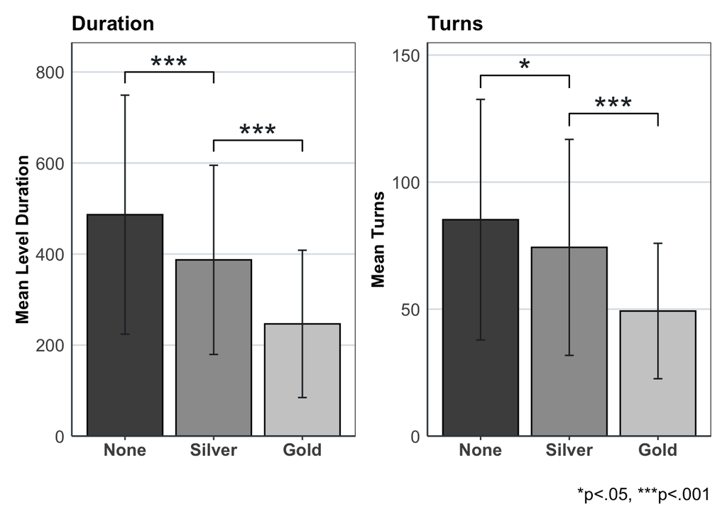

```r
library(patchwork)
durationPlots = fig1 + fig2
durationPlots
```

```r
# ggsave(filename = "Figs/trophy_levels_time.png",width = 8, height = 4.5, dpi = 300, units = "in", device='png')
```

Statistical significance tests

```r
library(lme4)
library(emmeans)
library(multcomp)
library(car)
```

```r
levBlotab3 = df.20.more %>% filter(utterlen_aligner < 71 & utterlen_target < 71) %>%
  dplyr::select(1:8, "numberturns") %>% unique()

levBlotab3 = levBlotab3 %>% mutate(TeamRE = paste0(Team, School))
a1 = lmer(level_duration ~ trophy + (1|TeamRE), levBlotab3); summary(a1); Anova(a1, type = 2)
```

```
## Linear mixed model fit by REML ['lmerMod']
## Formula: level_duration ~ trophy + (1 | TeamRE)
##    Data: levBlotab3
##
## REML criterion at convergence: 8484.1
##
## Scaled residuals:
##     Min      1Q  Median      3Q     Max
## -1.7167 -0.6896 -0.2166  0.4444  3.1235
##
## Random effects:
##  Groups   Name        Variance Std.Dev.
##  TeamRE   (Intercept)  6819     82.58
##  Residual             34199    184.93
## Number of obs: 635, groups:  TeamRE, 93
##
## Fixed effects:
##              Estimate Std. Error t value
## (Intercept)    216.35      20.69  10.456
## trophynone     161.27      21.72   7.426
## trophysilver   104.84      22.54   4.651
##
## Correlation of Fixed Effects:
##             (Intr) trphyn
## trophynone  -0.778
## trophysilvr -0.760  0.711
```

```
## Analysis of Deviance Table (Type II Wald chisquare tests)
##
## Response: level_duration
##         Chisq Df Pr(>Chisq)
## trophy 55.951  2  7.086e-13 ***
## ---
## Signif. codes:  0 '***' 0.001 '**' 0.01 '*' 0.05 '.' 0.1 ' ' 1
```

```r
a1.emm <- emmeans(a1, ~ trophy)
pairs(a1.emm, adjust = "none")
```

```
##  contrast      estimate   SE  df t.ratio p.value
##  gold - none     -161.3 21.7 597  -7.416  <.0001
##  gold - silver   -104.8 22.6 611  -4.642  <.0001
##  none - silver     56.4 16.9 599   3.346  0.0009
##
## Degrees-of-freedom method: kenward-roger
```

```r
## same as above, but cleaner and can be used with lmer if desired
# a1 = aov(level_duration ~ trophy, levBlotab3); summary(a1)
# pairwise.t.test(levBlotab3$level_duration, levBlotab3$trophy, p.adj = "bonf")

a2 = lmer(numberturns ~ trophy + (1|TeamRE), levBlotab3); summary(a2); Anova(a2, type = 2)
```

```
## Linear mixed model fit by REML ['lmerMod']
## Formula: numberturns ~ trophy + (1 | TeamRE)
##    Data: levBlotab3
##
## REML criterion at convergence: 6259.6
##
## Scaled residuals:
##     Min      1Q  Median      3Q     Max
## -1.6772 -0.6607 -0.2640  0.3704  4.4237
##
## Random effects:
##  Groups   Name        Variance Std.Dev.
##  TeamRE   (Intercept)  105.5   10.27
##  Residual             1062.3   32.59
## Number of obs: 635, groups:  TeamRE, 93
##
## Fixed effects:
##              Estimate Std. Error t value
## (Intercept)    39.852      3.434  11.606
## trophynone     20.970      3.784   5.542
## trophysilver   15.128      3.912   3.867
##
## Correlation of Fixed Effects:
##             (Intr) trphyn
## trophynone  -0.812
## trophysilvr -0.793  0.710
```

```
## Analysis of Deviance Table (Type II Wald chisquare tests)
##
## Response: numberturns
##         Chisq Df Pr(>Chisq)
## trophy 30.726  2  2.128e-07 ***
## ---
## Signif. codes:  0 '***' 0.001 '**' 0.01 '*' 0.05 '.' 0.1 ' ' 1
```

```r
a2.emm <- emmeans(a2, ~ trophy)
pairs(a2.emm, adjust = "none")
```

```
##  contrast      estimate   SE  df t.ratio p.value
##  gold - none     -20.97 3.79 613  -5.532  <.0001
##  gold - silver   -15.13 3.92 626  -3.858  0.0001
##  none - silver     5.84 2.94 616   1.988  0.0472
##
## Degrees-of-freedom method: kenward-roger
```

# DEEPER DIVE INTO DESCRIPTIVE DATA OF PERFORMANCE

#### Step 1

> Get a few stats on relationship between # of turns, trophy completions, and block

```r
## how many trophies distributed across all levels; how many blocks?
levtab1 = table(levels1$trophy); blotab1 = table(levels1$Block);

## how many trophies distributed across reduced levels; how many blocks?
levtab2 = table(levels2$trophy);  blotab2 = table(levels2$Block);

levtab1; levtab2
```

```
##
##   gold   none silver
##    306    459    324
```

```
##
##   gold   none silver
##    108    283    242
```

```r
blotab1; blotab2
```

```
##
## ExpBlock1 ExpBlock2    Warmup
##       377       439       273
```

```
##
## ExpBlock1 ExpBlock2    Warmup
##       214       234       185
```

```r
## What levels are dropped, based on TROPHY, when reducing by number of turns?

## how many levels were dropped BY TROPHIES after removing turns with 20 or fewer turns
# levtab1[1]-levtab2[1]; ((levtab1[1]-levtab2[1])/levtab1[1])*100
# levtab1[3]-levtab2[3]; ((levtab1[3]-levtab2[3])/levtab1[3])*100
# levtab1[2]-levtab2[2]; ((levtab1[2]-levtab2[2])/levtab1[2])*100
matA = matrix(c(names(levtab1[1]), levtab1[1], levtab2[1], ((levtab1[1]-levtab2[1])/levtab1[1])*100,
                names(levtab1[3]), levtab1[3], levtab2[3], ((levtab1[3]-levtab2[3])/levtab1[3])*100,
                names(levtab1[2]), levtab1[2], levtab2[2], ((levtab1[2]-levtab2[2])/levtab1[2])*100),
                ncol=4,byrow=TRUE)
colnames(matA) <- c("Trophy", "Original","Retained","% Drop")
matA
```

```
##      Trophy   Original Retained % Drop
## [1,] "gold"   "306"    "108"    "64.7058823529412"
## [2,] "silver" "324"    "242"    "25.3086419753086"
## [3,] "none"   "459"    "283"    "38.3442265795207"
```

```r
## What levels are dropped, based on BLOCK, when reducing by number of turns?

# blotab1[1]-blotab2[1]; ((blotab1[1]-blotab2[1])/blotab1[1])*100
# blotab1[3]-blotab2[3]; ((blotab1[3]-blotab2[3])/blotab1[3])*100
# blotab1[2]-blotab2[2]; ((blotab1[2]-blotab2[2])/blotab1[2])*100
matB = matrix(c("Warmup", blotab1[3], blotab2[3], ((blotab1[3]-blotab2[3])/blotab1[3])*100,
                "ExpBlock1", blotab1[1], blotab2[1], ((blotab1[1]-blotab2[1])/blotab1[1])*100,
                "ExpBlock2", blotab1[2], blotab2[2], ((blotab1[2]-blotab2[2])/blotab1[2])*100),
                ncol=4,byrow=TRUE)
colnames(matB) <- c("Block", "Original","Retained","% Drop")
matB
```

```
##      Block       Original Retained % Drop
## [1,] "Warmup"    "273"    "185"    "32.2344322344322"
## [2,] "ExpBlock1" "377"    "214"    "43.236074270557"
## [3,] "ExpBlock2" "439"    "234"    "46.6970387243736"
```

#### STEP 2

Repeat much of the above (stats on relationship between # of turns, trophy completions, and block) but in a format more easily used in paper and for interpretation

##### how many original levels; broken down by Block and Trophy

```r
main.data$trophy = factor(main.data$trophy, levels=c("none", "silver", "gold"))
main.data$Block = factor(main.data$Block, levels=c("Warmup", "ExpBlock1", "ExpBlock2"))

levels1.agg = main.data %>% group_by(Team, School, Block, Level, revisited, trophy) %>%
  summarise_if(is.numeric, list(~ mean(., na.rm = TRUE))); x1 = xtabs(~trophy + Block, levels1.agg)
x1
```

```
##         Block
## trophy   Warmup ExpBlock1 ExpBlock2
##   none      120       165       174
##   silver    107       103       114
##   gold       46       109       151
```

##### how many reduced levels after 20 or fewer turns; broken down by Block and Trophy

```r
levels2.agg = filter(main.data, numberturns >= rmTurns) %>% group_by(Team, School, Block, Level, revisited, trophy) %>%
  summarise_if(is.numeric, list(~ mean(., na.rm = TRUE))); x2 = xtabs(~trophy + Block, levels2.agg)
x2
```

```
##         Block
## trophy   Warmup ExpBlock1 ExpBlock2
##   none       75       107       101
##   silver     84        74        84
##   gold       26        33        49
```

##### report above as a percentage (dropped vs. retained)

```r
droplevel = ((x1-x2)/x1)*100; droplevel
```

```
##         Block
## trophy     Warmup ExpBlock1 ExpBlock2
##   none   37.50000  35.15152  41.95402
##   silver 21.49533  28.15534  26.31579
##   gold   43.47826  69.72477  67.54967
```

```r
droplevel2 = ((x2)/x1)*100; droplevel2
```

```
##         Block
## trophy     Warmup ExpBlock1 ExpBlock2
##   none   62.50000  64.84848  58.04598
##   silver 78.50467  71.84466  73.68421
##   gold   56.52174  30.27523  32.45033
```

##### how many levels removed

```r
levels2.agg = filter(main.data, numberturns < rmTurns) %>% group_by(Team, School, Block, Level, revisited, trophy) %>%
  summarise_if(is.numeric, list(~ mean(., na.rm = TRUE))); x3 = xtabs(~trophy + Block, levels2.agg)
x3
```

```
##         Block
## trophy   Warmup ExpBlock1 ExpBlock2
##   none       45        58        73
##   silver     23        29        30
##   gold       20        76       102
```

What is the story emerging from above? How does this change any of the analyses attempting to do? As implications when trying to relate language dynamics, that require temporal component of at least 20 turns to develop, to performance outcomes.

```r
# First, way more levels are attempted from block to block
colSums(x1)
```

```
##    Warmup ExpBlock1 ExpBlock2
##       273       377       439
```

```r
# But this gets equalized out some after removing levels with 20 or less turns
colSums(x2)
```

```
##    Warmup ExpBlock1 ExpBlock2
##       185       214       234
```

```r
# This shows the reduction. Although more levels are dropped from ExpBlock2, not that dramatic
matB
```

```
##      Block       Original Retained % Drop
## [1,] "Warmup"    "273"    "185"    "32.2344322344322"
## [2,] "ExpBlock1" "377"    "214"    "43.236074270557"
## [3,] "ExpBlock2" "439"    "234"    "46.6970387243736"
```

```r
# There is also a good distribution of levels with different performance outcomes
rowSums(x1)
```

```
##   none silver   gold
##    459    324    306
```

```r
# But this gets reduced quite a bit with 20 or less turns
rowSums(x2)
```

```
##   none silver   gold
##    283    242    108
```

```r
# This shows the reduction. Many more gold levels are dropped, followed by none levels
matA
```

```
##      Trophy   Original Retained % Drop
## [1,] "gold"   "306"    "108"    "64.7058823529412"
## [2,] "silver" "324"    "242"    "25.3086419753086"
## [3,] "none"   "459"    "283"    "38.3442265795207"
```

First the raw distribution of levels as trophy by block, overall. Clearly gold trophies really ramp up from Warmup to ExpBlock2, silver trophies stay constant, and none levels increase as well. Much has to do with the fact that more levels are attempted from block to block

```r
x1
```

```
##         Block
## trophy   Warmup ExpBlock1 ExpBlock2
##   none      120       165       174
##   silver    107       103       114
##   gold       46       109       151
```

This is a better look as a percentage of overall levels based on those attempted in each block. Interestingly, of those attempted, silver actually decreases while gold goes up. None stays constant.

```r
t(t(x1)/colSums(x1))
```

```
##         Block
## trophy      Warmup ExpBlock1 ExpBlock2
##   none   0.4395604 0.4376658 0.3963554
##   silver 0.3919414 0.2732095 0.2596811
##   gold   0.1684982 0.2891247 0.3439636
```

> Now, the raw distribution of levels as trophy by block in the reduced set.

```r
x2
```

```
##         Block
## trophy   Warmup ExpBlock1 ExpBlock2
##   none       75       107       101
##   silver     84        74        84
##   gold       26        33        49
```

> And what it looks like in terms of levels as trophy by block for those actually attempted in the reduced set. Sort of same pattern as the original, but just not as pronounced.

```r
t(t(x2)/colSums(x2))
```

```
##         Block
## trophy      Warmup ExpBlock1 ExpBlock2
##   none   0.4054054 0.5000000 0.4316239
##   silver 0.4540541 0.3457944 0.3589744
##   gold   0.1405405 0.1542056 0.2094017
```

> Why not as pronounced, because there are a lot of levels dropped in the gold and not so much in silver. The most affected is gold trophies in the later blocks.

> Lots of levels with gold trophies are removed (implication: people are relying on non-verbal cues for these); relatively way fewer silver trophies were removed (in fact, more failed levels than those getting silver: implication: silver levels have lots of language relative to gold levels)

```r
droplevel = ((x1-x2)/x1)*100; droplevel
```

```
##         Block
## trophy     Warmup ExpBlock1 ExpBlock2
##   none   37.50000  35.15152  41.95402
##   silver 21.49533  28.15534  26.31579
##   gold   43.47826  69.72477  67.54967
```

> One more look, just confirms that golds really have fewer words. Followed by silver with second most, and none with the most. Also shows trends where the number of words drops off across blocks

```r
levBlotab = main.data %>% group_by(factor(trophy, levels=c("none", "silver", "gold")), factor(Block, levels=c("Warmup", "ExpBlock1", "ExpBlock2"))) %>% summarise(mean(numberturns)); colnames(levBlotab) <- c("Trophy", "Block", "AvgNumTurns"); levBlotab
```

```
## # A tibble: 9 × 3
## # Groups:   Trophy [3]
##   Trophy Block     AvgNumTurns
##   <fct>  <fct>           <dbl>
## 1 none   Warmup           82.4
## 2 none   ExpBlock1        84.4
## 3 none   ExpBlock2        70.1
## 4 silver Warmup           78.7
## 5 silver ExpBlock1        69.7
## 6 silver ExpBlock2        60.4
## 7 gold   Warmup           50.3
## 8 gold   ExpBlock1        30.8
## 9 gold   ExpBlock2        35.9
```

```r
lev_duration = main.data %>% group_by(factor(trophy, levels=c("none", "silver", "gold")), factor(Block, levels=c("Warmup", "ExpBlock1", "ExpBlock2"))) %>% summarise(mean(level_duration)); colnames(lev_duration) <- c("Trophy", "Block", "AvgDuration"); lev_duration
```

```
## # A tibble: 9 × 3
## # Groups:   Trophy [3]
##   Trophy Block     AvgDuration
##   <fct>  <fct>           <dbl>
## 1 none   Warmup           506.
## 2 none   ExpBlock1        467.
## 3 none   ExpBlock2        397.
## 4 silver Warmup           415.
## 5 silver ExpBlock1        362.
## 6 silver ExpBlock2        318.
## 7 gold   Warmup           272.
## 8 gold   ExpBlock1        148.
## 9 gold   ExpBlock2        174.
```

```r
df.20.more = filter(main.data, numberturns >= rmTurns)

levBlotab2 = df.20.more %>% group_by(factor(trophy, levels=c("none", "silver", "gold")), factor(Block, levels=c("Warmup", "ExpBlock1", "ExpBlock2"))) %>% summarise(mean(level_duration), mean(numberturns)); colnames(levBlotab2) <- c("Trophy", "Block", "AvgDuration", "AvgNumTurns"); levBlotab2
```

```
## # A tibble: 9 × 4
## # Groups:   Trophy [3]
##   Trophy Block     AvgDuration AvgNumTurns
##   <fct>  <fct>           <dbl>       <dbl>
## 1 none   Warmup           535.        87.9
## 2 none   ExpBlock1        497.        90.1
## 3 none   ExpBlock2        433.        76.8
## 4 silver Warmup           433.        82.4
## 5 silver ExpBlock1        384.        74.5
## 6 silver ExpBlock2        337.        64.3
## 7 gold   Warmup           304.        56.7
## 8 gold   ExpBlock1        218.        43.8
## 9 gold   ExpBlock2        227.        47.8
```

OTHER: CAN BE IGNORED

```r
# levels1 = df.sl2 %>% select(Team, School, aligner_score) %>% distinct()
# levels2 = df.sl2 %>% select(Team, School, block_manip, Level, revisited, numberturns) %>% distinct()
#
# quantile(levels2$numberturns)
# IQR(levels2$numberturns)
#
# duration = levels2$numberturns
# breaks = seq(5, 200, by=5)
# duration.cut = cut(duration, breaks, right=FALSE)
# duration.freq = table(duration.cut)
# duration.cumfreq = cumsum(duration.freq)
#
# duration.cumrelfreq = duration.cumfreq / nrow(levels2) *100
# duration.cumrelfreq
```